# LTV/CAC > 3xに関する調べごと

UPDATE: 2023-09-10 19:13:35

# はじめに

このノートでは、SaaSのユニットエコノミクスの話に関連して頻出する「LTV/CAC > 3x」に関して、どうすれば3よりも大きくできるかを考えた際の内容をまとめている。今回はRや分析の話は出てこない・・・。

## ユニットエコノミクス`LTV/CAC`とは？

そもそもユニットエコノミクス`LTV/CAC`とは何か。計算式を見る限り`LTV`と`CAC`の比率によって構成されている指標であることはわかる。つまり、顧客から得られる利益と顧客獲得コストを比較し、投資対効果として採算がとれている状態なのかを表現している指標と言えそう。

分子の`LTV`は顧客生涯価値と呼ばれるやつで、契約後から累計で支払ってくれる金額の大きさの推定値であり、分母の`CAC(Customer Acquisition Cost)`は1つの新規契約にかかる広告費や販促費、それに関わる人件費を考慮した指標のこと。広告のCVあたり単価`CPA`とは異なるので注意。

`LTV`は、SaaS界隈では一般的に下記のように計算される。この計算式が正しいかどうかは議論があるが、上場SaaS企業でも使われている計算式だったりする。`LTV`は、契約期間(ContractPeriod)、顧客単価(ARPU)、粗利率(GrossMarginRate)の掛け合わせで表現される。

$$LTV = ContractPeriod \times ARPU \times GrossMarginRate = \frac{ARPU
\times GrossMarginRate}{ChurnRate}$$

また、`CAC`は、セールス&マーケ費用(S&M Cost)、新規顧客獲得数(#NewCustomersAcquired)の比で表現される。`CAC`はおそらく一般的に、有料チャネル経由の顧客獲得と自然経由の顧客獲得を合わせた`Blended CAC`を指す(はず)。

$$CAC = \frac{S\&M\ Cost}{\#NewCustomersAcquired}$$

`CAC`は、期間を限定して算出する。例えば、四半期決算であれば3ヶ月という期間を設定し、その期間の中で、顧客獲得にかかったS&M Costを新規顧客数で割ることで計算する。例えば、3カ月と期間を設定し、その期間のS&M費用が900万円だっだとする。顧客数が300であれば、`CAC`は3万円となる。期間を分割することで、期間を変更した場合には、期間内の偏りによって数値も変動するので注意。そして、これらを用いてユニットエコノミクスは計算される。

$$Unit Economics = \frac{LTV}{CAC}$$

つまり、`CAC`が小さく、`LTV`が大きければユニットエコノミクスは大きくなる。言い換えると、新規契約顧客を広告費を掛けず、人件費も掛けずに獲得し、プロダクトを長く、エクスパンションさせられるような関係性を構築できれば、ユニットエコノミクスは大きくなる。

## なぜ`LTV/CAC > 3x`が良いのか？

詳しい話は、下記のWantedly社取締役の方の記事が参考になる。

- [SaaSの公式「LTV/CAC > 3x」ってなんでなの？分解して考えてみた。](https://www.wantedly.com/companies/wantedly/post_articles/136733)

上記の話を理解するためには、新たな指標を説明する必要がある。それは、CAC回収期間(CAC Payback Period)と呼ばれる、1顧客獲得にかけたコストを何ヶ月で回収できるかを表す指標。

$$CAC \ Payback Period = \frac{CAC}{ARPU}$$

例えば、`CAC`は3万円で、ARPUが1万円の場合、CAC回収期間は3ヶ月となる。また、下記の関係が成り立つ。

$$\frac{LTV}{CAC} = \frac{ARPU \times ContractPeriod}{ARPU \times CAC \
Payback Period} = \frac{ContractPeriod}{CAC \ Payback Period}$$

参照先の記事にあるように、`LTV/CAC = 3`であれば、下記のような状態となる。

> 先述の式から、LTV/CACが3倍ということは、CAC回収期間が12ヶ月なら平均継続期間が36ヶ月となりますよね。これはChurn Rateで言うと2.8%です（1/36 = 2.777…%） 顧客の規模にもよりますが、B2B SaaSの場合、月次のChurn Rateは3%未満が望ましいと言われています。（参考：SaaS事業の成長可能性を判断する、3つの指標 | 500 Startups Japan） なんと、健全な水準と言われる「CAC回収期間12ヶ月」と「Churn Rate 3%未満」を満たすと、概ね「LTV/CAC > 3x」が成立することが分かりました！

要するにBtoB SaaSであれば、一般的にチャーンレートは3%以下が良いとか、CAC回収期間は12カ月までが一般的な目安とか言われており、基本的にはチャーンレートは3%以下は`LTV/CAC = 3`のときに成り立つ、ということらしい。反対に、基本的にはチャーンレート3％以下のとき、ユニットエコノミクスが3以上であることが期待される。

実際、上場しているSaaS企業の場合、ユニットエコノミクスは3を超えていることが多い。ユニットエコノミクスを公開しているカオナビ社の[2024年3月期 第1四半期決算説明資料](https://ssl4.eir-parts.net/doc/4435/yuho_pdf/S100RLRF/00.pdf)を見ると、直近では10を超えていることがわかる。

非常に効率よく投資したお金を回収できていることになる。

## どうすれば3よりも大きくなるのか？

ユニットエコノミクスが3以上だと良いことが理解できたが、どうすれば3よりも大きくなるのか。その点をここから考えていく。ユニットエコノミクスは、さらに式変形を進めると、下記のようにも表現できる。

$$\begin{eqnarray}
Unit Economics &=& \frac{LTV}{CAC} \\
&=& \frac{ContractPeriod \times ARPU \times
GrossMarginRate}{\frac{S\&M\ Cost}{\#NewCustomersAcquired}} \\
&=& \frac{(ContractPeriod \times ARPU \times GrossMarginRate)
\times \#NewCustomersAcquired}{S\&M\ Cost}
\end{eqnarray}$$

このように式変形をすると見通しが良い。この式はSaaS企業の基本的な人的配置を表現しているとも解釈できる。分子の括弧内はカスタマーサクセスと開発部門、残りの分子と分母はセールスとマーケティングである。

カスタマーサクセスチームは、顧客の収益性を最大化するために、長期的な関係を築くことが重要になる。その中で、アップセルとクロスセルを行い、顧客に対して、追加機能やサービスを提供することで、顧客の支出を増やしながら、チャーンせずに顧客がサービスを継続的に利用し続けるために、オンボーディングやカスタマーサポートを提供し、サービスの満足度を高めてサクセスへと導く。また、開発チームはカスタマーサクセスを通じて得られる要望をもとに、製造原価を抑えながら、必要な機能を追加で開発する。これらの取り組みにより、分子の括弧内の数字は最大化されることになる。

次に、分子の残りと分母については、セールスとマーケティングの担当になる。やるべきことは、多くのリードを獲得して新規顧客の契約に繋げ、かつ、少ない費用で行う。そうすることで、分子の残りが大きくなり、分母が小さくなることで、ユニットエコノミクスは最大化される。つまるところ、マーケティングに必要とされる一般的な活動を効率的に取り組むことになる。

- ターゲット市場の特定:どの顧客層をターゲットにするかを明確に特定する。
- 競合分析:競合他社のマーケティング戦略やバリュープロポジションを調査し、自社の競争力を理解する。
- セグメンテーション:顧客セグメンテーションを行い、異なる顧客グループに対して異なるアプローチを取る。
- カスタマージャーニー:顧客が商品やサービスを知り、購入までの過程を詳細にマッピングする。
- マーケティングオートメーション:カスタマージャーニーをもとにMAで効率的なリードの獲得、成長、刈り取りを行う。
- データドリブンな意思決定:広告キャンペーン、ランディングページ、コンテンツなどの要素に対してA/Bテストを実施し、データを活用してマーケティング戦略を最適化する。
- リファラルプログラムの導入:既存顧客から新規顧客を紹介してもらう仕組みを設ける。
- コンテンツマーケティング:有益なコンテンツを提供して、ターゲット顧客の興味を引きつけます。ブログ記事、ホワイトペーパー、ウェビナーなどのコンテンツを活用し、顧客の教育や説明に役立てる。
- 効果のモニタリングと最適化:キャンペーンの効果を継続的にモニタリングし、最も効果的なチャネルや広告キャンペーンに予算をアロケーションする。
- 継続的な改善:上記を継続的に改善する。市場状況や競争状況が変化するたびに、戦略を見直し、CACを小さくするように努める。

ユニットエコノミクスは、SaaSの各チームの機能をうまく表現している計算式といえる。各項目は各チームの目標とされるような数値なので、各チームが成果を出し続けることで、ユニットエコノミクスはどんどん大きくなる。

## おまけ

カオナビ社の[2024年3月期 第1四半期決算説明資料](https://ssl4.eir-parts.net/doc/4435/yuho_pdf/S100RLRF/00.pdf)からユニットエコノミクスを手計算したもの。赤カラムは決算書の数字、青、黄カラムは私が計算したもの。私が計算した部分で、一部、決算書の数字と合わないのは、正確な細かい数字をもとに計算にしたものではなく、決算書に記載されている数字を再利用して計算しているためだと思われる。

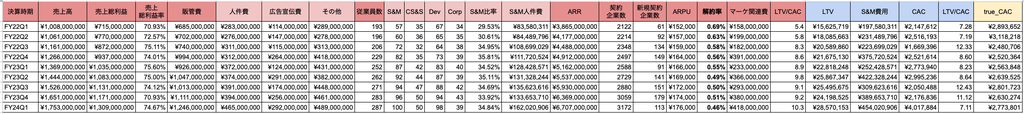

FY24第1四半期決算説明資料

## 参考文献

- [LTVとCACの比率 ：SaaSビジネスの基礎知識- Baremetrics Japan](https://baremetrics.com/jp/blog/what-is-the-ltv-to-cac-ratio)
- [SaaSの公式「LTV/CAC > 3x」ってなんでなの？分解して考えてみた。](https://www.wantedly.com/companies/wantedly/post_articles/136733)
- [【徹底解説】SaaS企業のLTVとCAC、ユニットエコノミクスの計算方法](https://timeskip.co.jp/sales/sales-organization/unit-economics)